# Supervised project

Michele Bartesaghi

2022-06-10

In this data set, data are collected to study the effects that smoking has on the human body. The aim of the project is to identify these effects and use those body signals to predict whether an individual is smoking or not

Data shape : (55692, 27)

- ID
- gender
- age
- height(cm)
- weight(kg)
- waist(cm)
- eyesight(left)
- eyesight(right)
- hearing(left)
- hearing(right)
- systolic
- relaxation
- fasting blood sugar
- Cholesterol
- triglyceride
- HDL
- LDL
- hemoglobin
- Urine protein
- serum creatinine
- AST
- ALT (AST is found in the liver, brain, pancreas, heart, kidneys, lungs, and skeletal muscles. ALT is found mainly in the liver)
- Gtp
- oral
- dental caries
- tartar
- smoking

#Import the libraries

```r
library(readxl)
library(ggplot2)
library(plyr)
library(dplyr)
library(ggthemes)
library(tidyr)
library(tidyverse)
library(data.table)
library(ggpubr)
library(patchwork)
library(scales)
library(corrplot)
library(MASS)
library(DataExplorer)
library(car)
library(olsrr)
library(caret)
library(gtools)
library(psych)
library(tree)
library(ISLR)
library(rpart)
library(rpart.plot)
library(partykit)
library(randomForest)
library(class)
library(caTools)
library(ROCR)
library(plotly)
library(party)
#custom function for accuracy
accuracy <- function(x){sum(diag(x)/(sum(rowSums(x)))) * 100}
```

#IMPORT DATA, visualisation and preprocessing

```r
smoke <- as_tibble(readr::read_csv("C:/Users/pc/Desktop/UNIMI- DSE/Corsi singoli/Machine Learning, Statistical Learning, Deep Learning, Cloud Distributed Computing and AI/Statistical methods for ML module/First personal project/smoking.csv", show_col_types = FALSE))

#transform in factors the variables that should be factors
smoke$gender <- as.factor(smoke$gender)
smoke$`hearing(left)` <- as.factor(smoke$`hearing(left)`)
smoke$`hearing(right)` <- as.factor(smoke$`hearing(left)`)
smoke$`Urine protein` <- as.factor(smoke$`Urine protein`)
smoke$oral <- as.factor(smoke$oral)
smoke$`dental caries` <- as.factor(smoke$`dental caries`)
smoke$tartar <- as.factor(smoke$tartar)
smoke$smoking <- as.factor(smoke$smoking)

#remove both ID and oral, which is useless
#ID is simply a numeric, meaningless identifier
#oral is a one level factor
smoke <- smoke %>% dplyr::select(-c(ID,oral))


#rename the columns
cn <- c("gender","age","height","weight","waist","eyesight_L","eyesight_R","hearing_L","hearing_R", "systolic","relaxation","sugar","cholesterol","triglyceride","HDL","LDL","hemoglobin","urine_protein","serum_creatinine","AST","ALT","Gtp", "caries","tartar","smoking")
colnames(smoke) <- cn
rm(cn)
#set smoking as the first column
smoke <- smoke %>% relocate(smoking)

#glimpse(smoke)
#anyNA(smoke)   #no NA's
```

#Check for outliers with boxplots

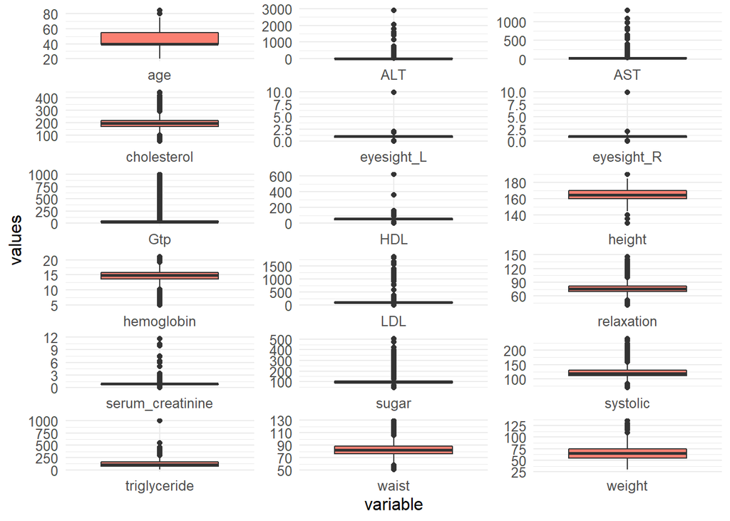

```r
#prepare a boxplot for every numeric variable
#select numeric features
smoke_num <- select_if(smoke,is.numeric)
#create a tibble with two columns: the feature name and the values
smoke_num_box <-smoke_num %>% gather(variable,values,1:18)

ggplot(smoke_num_box)+
  geom_boxplot(aes(x=variable,y=values), fill="Salmon") +
  facet_wrap(~variable,ncol=3,scales="free") +
  theme_minimal()+
  theme(strip.text.x = element_blank(),
        text = element_text(size=12))
```

```r
summary(boxplot.stats(smoke$age))
```

```
##       Length Class  Mode
## stats   5    -none- numeric
## n       1    -none- numeric
## conf    2    -none- numeric
## out   295    -none- numeric
```

```r
summary(boxplot.stats(smoke$eyesight_L))
```

```
##       Length Class  Mode
## stats    5   -none- numeric
## n        1   -none- numeric
## conf     2   -none- numeric
## out   1314   -none- numeric
```

```r
summary(boxplot.stats(smoke$eyesight_R))
```

```
##       Length Class  Mode
## stats    5   -none- numeric
## n        1   -none- numeric
## conf     2   -none- numeric
## out   1357   -none- numeric
```

```r
summary(boxplot.stats(smoke$HDL))
```

```
##       Length Class  Mode
## stats    5   -none- numeric
## n        1   -none- numeric
## conf     2   -none- numeric
## out   1011   -none- numeric
```

```r
summary(boxplot.stats(smoke$height))
```

```
##       Length Class  Mode
## stats   5    -none- numeric
## n       1    -none- numeric
## conf    2    -none- numeric
## out   249    -none- numeric
```

```r
summary(boxplot.stats(smoke$ALT))
```

```
##       Length Class  Mode
## stats    5   -none- numeric
## n        1   -none- numeric
## conf     2   -none- numeric
## out   3710   -none- numeric
```

```r
summary(boxplot.stats(smoke$triglyceride))
```

```
##       Length Class  Mode
## stats    5   -none- numeric
## n        1   -none- numeric
## conf     2   -none- numeric
## out   2256   -none- numeric
```

```r
#the count of outliers rather large for every variable, therefore these points
#cannot be considered as outliers
```

#Some data visualisation

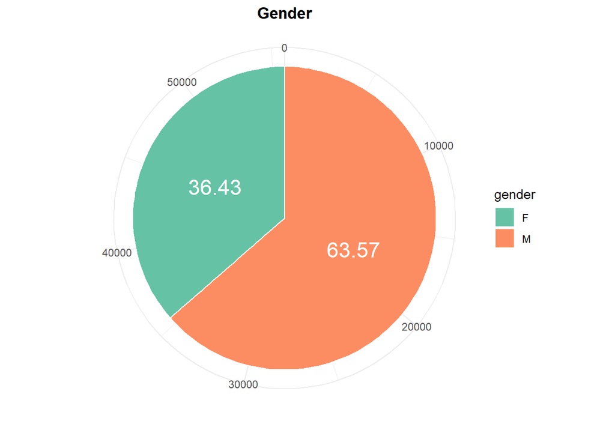

```r
#gender visualisation
male_perc <- nrow(smoke %>% dplyr::select(gender) %>%
                    filter(gender == "M"))/length(smoke$gender)*100
female_perc <- nrow(smoke %>% dplyr::select(gender) %>%
                      filter(gender == "F"))/length(smoke$gender)*100

pgen <- smoke %>%
  count(gender) %>%
  mutate("perc" = round(c(female_perc,male_perc),2))

pgen <- pgen %>%
  arrange(desc(gender)) %>%
  mutate(prop = n / sum(pgen$perc) *100) %>%
  mutate(ypos = cumsum(prop)- 0.5*prop )

ggplot(pgen, aes(x="", y=n, fill=gender)) +
  geom_bar(stat="identity", width=1,color="white")+
  coord_polar("y",0,1)+
  labs(x = "", y = "",title="Gender")+
  theme_minimal()+ # remove background, grid, numeric labels
  theme(plot.title=element_text(face="bold",  hjust=0.5))+
  geom_text(aes(y = ypos, label = perc), color = "white", size=6) +
  scale_fill_brewer(palette="Set2")
```

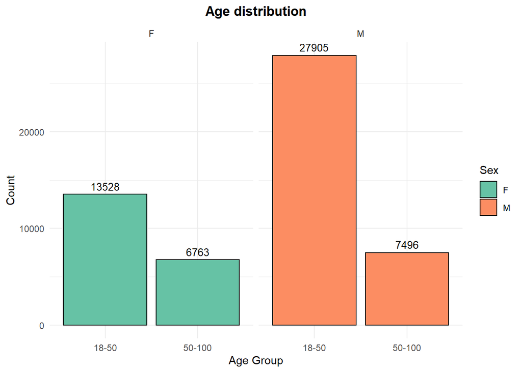

```r
#age for different genders
smoke$age_group <- cut(smoke$age, c(0,18,50,100,120), labels = c("<18","18-50","50-100",">100") )

ggplot(smoke,aes(x=age_group, fill=gender))+
  geom_bar(col="black")+
  facet_wrap(.~gender)+
  stat_count(aes(y=..count.., label=..count..), vjust=-0.5,geom="text", col="black", size=3.5)+
  labs(x="Age Group", y = "Count", title="Age distribution", fill= "Sex")+
  theme_minimal()+
  theme(plot.title=element_text(face="bold",  hjust=0.5))+
  scale_fill_brewer(palette="Set2")
```

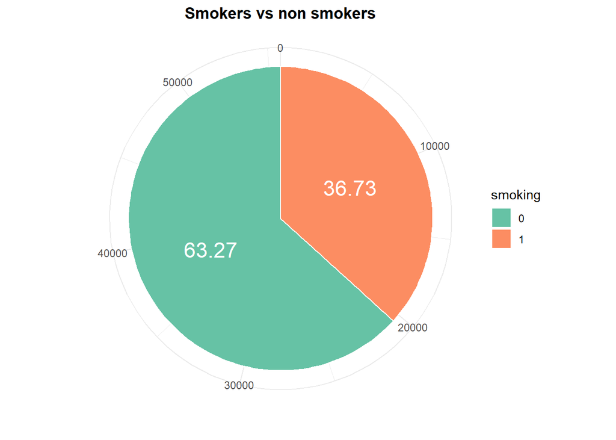

```r
#smoking
smoke_perc <- nrow(smoke %>% dplyr::select(smoking) %>%
                    filter(smoking == 1))/length(smoke$smoking)*100
nonsmoke_perc <- nrow(smoke %>% dplyr::select(smoking) %>%
                      filter(smoking == 0))/length(smoke$smoking)*100

pgen <- smoke %>%
  count(smoking) %>%
  mutate("perc" = round(c(nonsmoke_perc,smoke_perc),2))

pgen <- pgen %>%
  arrange(desc(smoking)) %>%
  mutate(prop = n / sum(pgen$perc) *100) %>%
  mutate(ypos = cumsum(prop)- 0.5*prop )

ggplot(pgen, aes(x="", y=n, fill=smoking)) +
  geom_bar(stat="identity", width=1,color="white")+
  coord_polar("y",0,1)+
  labs(x = "", y = "",title="Smokers vs non smokers")+
  theme_minimal()+ # remove background, grid, numeric labels
  theme(plot.title=element_text(face="bold",  hjust=0.5))+
  geom_text(aes(y = ypos, label = perc), color = "white", size=6) +
  scale_fill_brewer(palette="Set2")
```

```r
#overall
overall <- smoke %>%
  group_by(gender,smoking) %>%
  summarise(avg_age = round(mean(age),0), avg_height = round(mean(height),0), avg_weight = round(mean(`weight`),0))
xtable::xtable(overall)
```

```
## % latex table generated in R 4.1.2 by xtable 1.8-4 package
## % Wed Jun 29 12:58:14 2022
## \begin{table}[ht]
## \centering
## \begin{tabular}{rllrrr}
##   \hline
##  & gender & smoking & avg\_age & avg\_height & avg\_weight \\
##   \hline
## 1 & F & 0 & 49.00 & 156.00 & 56.00 \\
##   2 & F & 1 & 46.00 & 157.00 & 56.00 \\
##   3 & M & 0 & 42.00 & 170.00 & 71.00 \\
##   4 & M & 1 & 41.00 & 170.00 & 72.00 \\
##    \hline
## \end{tabular}
## \end{table}
```

```r
#Heart implications
#(https://www.heart.org/en/health-topics/high-blood-pressure/understanding-blood-pressure-readings)

smoke$pressure <- ifelse(smoke$systolic<120 & smoke$relaxation<80,"Normal",NA)
smoke$pressure <- ifelse(smoke$systolic>=120 & smoke$relaxation <80, "Elevated",smoke$pressure)
smoke$pressure <- ifelse(smoke$systolic>=130 | smoke$relaxation>=80,"Hypertension Stage 1",smoke$pressure)
smoke$pressure <- ifelse(smoke$systolic>=140 | smoke$relaxation>=90,"Hypertension Stage 2",smoke$pressure)
smoke$pressure <- ifelse(smoke$systolic>=180 | smoke$relaxation>=120,"Hypertensive Crisis",smoke$pressure)

table <- smoke %>%
  mutate(`Blood Pressure`= smoke$pressure) %>%
  group_by(`Blood Pressure`)%>%
  summarise(smokers= length(smoking[smoking=="1"]),
            `non smokers`= length(smoking[smoking=="0"]),
            `smokers percentage`= round(smokers/sum(smokers,`non smokers`)*100,0))%>%
  arrange(desc(`smokers percentage`))
table
```

```
## # A tibble: 5 x 4
##   `Blood Pressure`     smokers `non smokers` `smokers percentage`
##   <chr>                  <int>         <int>                <dbl>
## 1 Hypertensive Crisis       44            59                   43
## 2 Hypertension Stage 1    7869         10866                   42
## 3 Hypertension Stage 2    2103          3404                   38
## 4 Elevated                2766          4910                   36
## 5 Normal                  7673         15998                   32
```

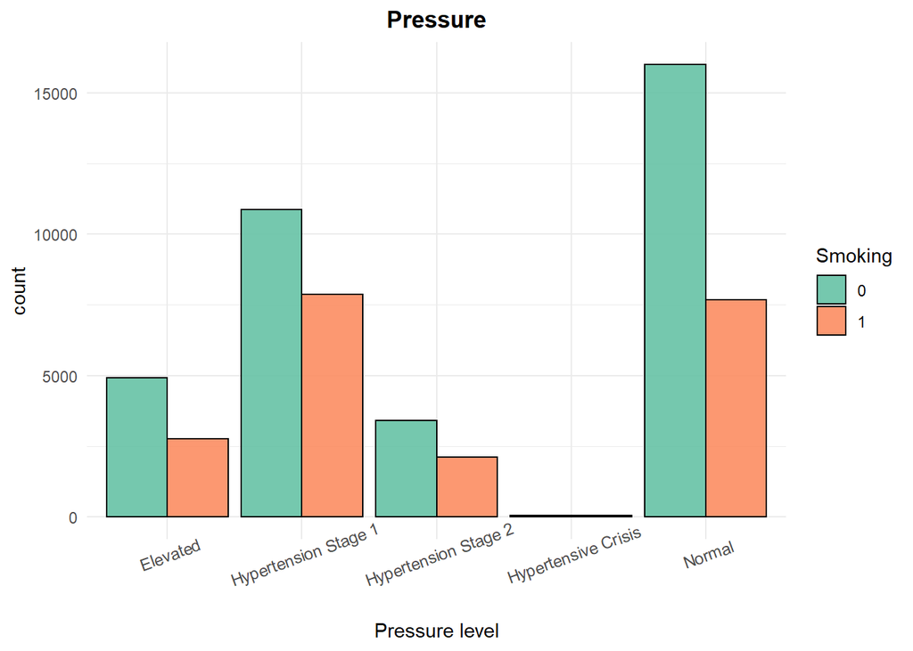

```r
ggplot(smoke, aes(x= pressure, fill = smoking))+
  geom_bar(position = "dodge", col = "black", alpha=0.9)+
  scale_fill_brewer(palette="Set2")+
  labs(title="Pressure", fill="Smoking", x="Pressure level")+
  theme_minimal()+
  theme(plot.title = element_text(face="bold", hjust=0.5),
        axis.text.x = element_text(size= 9, angle = 20))
```

```r
#body mass index
smoke$bmi <- (smoke$weight/(smoke$height*smoke$height))*10000
smoke$bmi_cat <- ifelse(smoke$bmi<18.5,"Underweight", NA )
smoke$bmi_cat <- ifelse(smoke$bmi>=18.5 & smoke$bmi <=24.9,"Healthy BMI", smoke$bmi_cat )
smoke$bmi_cat <- ifelse(smoke$bmi > 24.9 & smoke$bmi<=29.9,"Overweight", smoke$bmi_cat)
smoke$bmi_cat <- ifelse(smoke$bmi > 30 & smoke$bmi<=39.9, "Obese", smoke$bmi_cat)
smoke$bmi_cat <- ifelse(smoke$bmi > 40, "Extremely Obese", smoke$bmi_cat)
table(smoke$bmi_cat)
```

```
##
## Extremely Obese     Healthy BMI           Obese      Overweight     Underweight
##              12           32773            2911           18278            1718
```

```r
smoke %>%  filter(bmi > 40) %>%  dplyr::select(bmi_cat,smoking)
```

```
## # A tibble: 12 x 2
##    bmi_cat         smoking
##    <chr>           <fct>
##  1 Extremely Obese 1
##  2 Extremely Obese 0
##  3 Extremely Obese 1
##  4 Extremely Obese 0
##  5 Extremely Obese 0
##  6 Extremely Obese 1
##  7 Extremely Obese 1
##  8 Extremely Obese 1
##  9 Extremely Obese 0
## 10 Extremely Obese 0
## 11 Extremely Obese 0
## 12 Extremely Obese 1
```

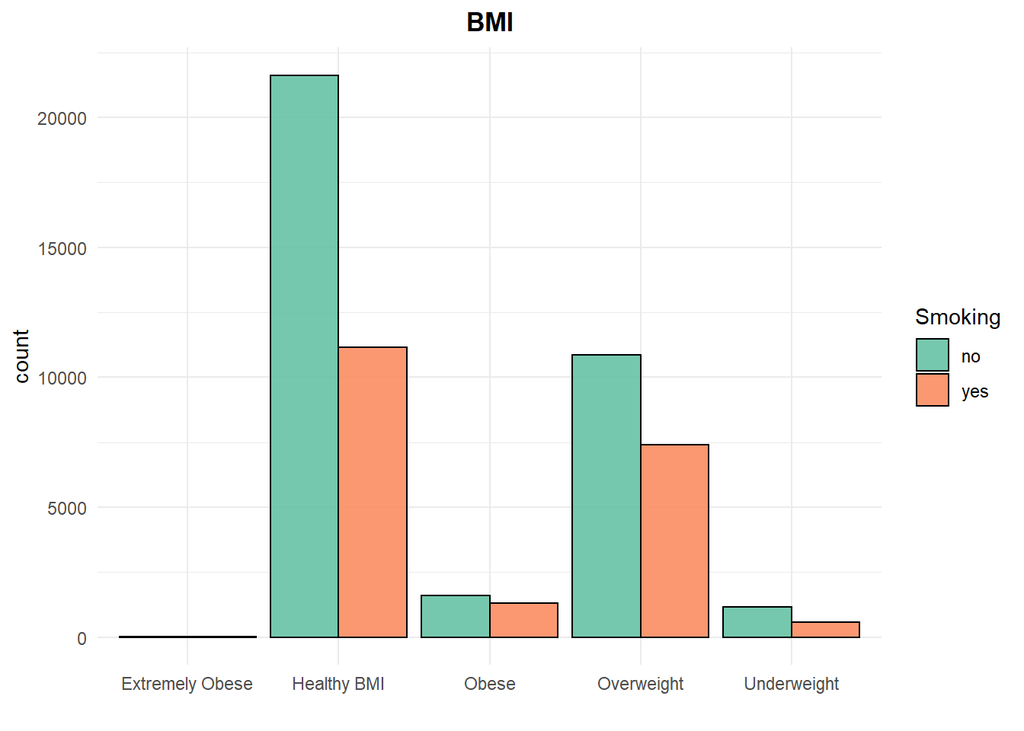

```r
ggplot(smoke, aes(x=bmi_cat, fill= as.factor(smoking)))+
  geom_bar(position="dodge", col="black", alpha=0.9)+
  scale_fill_brewer(label=c("no","yes"),palette="Set2")+
  labs(x=" ", fill="Smoking", title="BMI")+
  theme_minimal()+
  theme(plot.title= element_text(face = "bold", hjust=0.5))
```

```r
#ldl levels
smoke$LDL_stat <- case_when(
    smoke$LDL<100 ~ "Optimal",
    smoke$LDL >= 100 & smoke$LDL < 130 ~ "Near optimal",
    smoke$LDL >=130 & smoke$LDL < 159 ~ "Borderline high",
    smoke$LDL >=159 & smoke$LDL < 190 ~ "High",
    smoke$LDL >= 190 ~ "Very high")
table(smoke$smoking, smoke$LDL_stat)
```

```
##
##     Borderline high  High Near optimal Optimal Very high
##   0            7679  2884        12596   11365       713
##   1            4202  1406         6930    7538       379
```

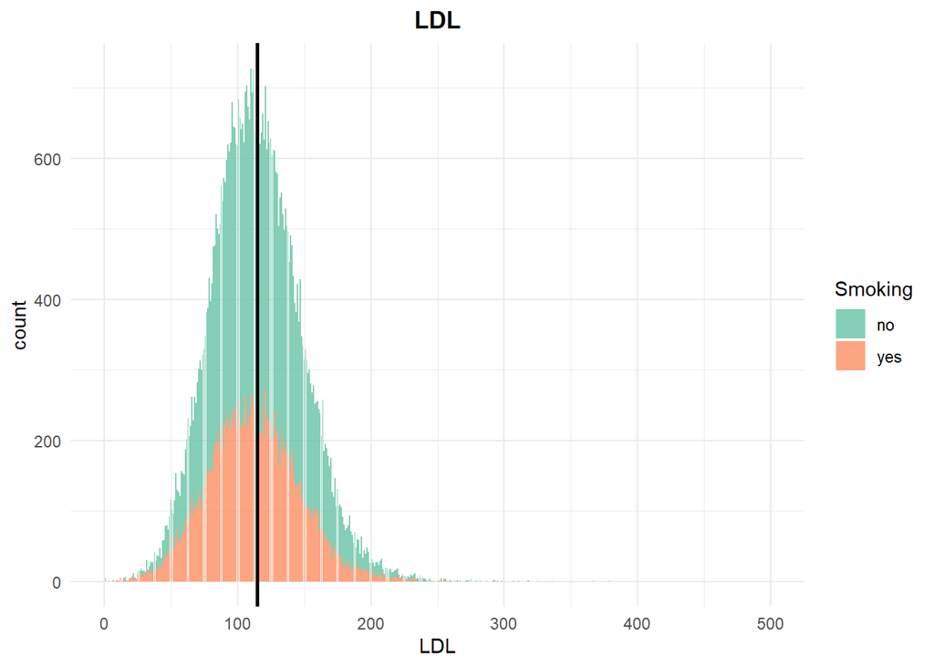

```r
ggplot(smoke, aes(x=LDL, fill=smoking))+
  geom_bar(alpha=0.8)+
  labs(title="LDL", fill="Smoking")+
  theme_minimal()+
  theme(plot.title = element_text(face="bold", hjust=0.5))+
  scale_fill_brewer(label=c("no","yes"),palette="Set2")+
  geom_vline(aes(xintercept=mean(smoke$LDL)), col = "black", lwd = 1)+
  xlim(c(0,500))
```

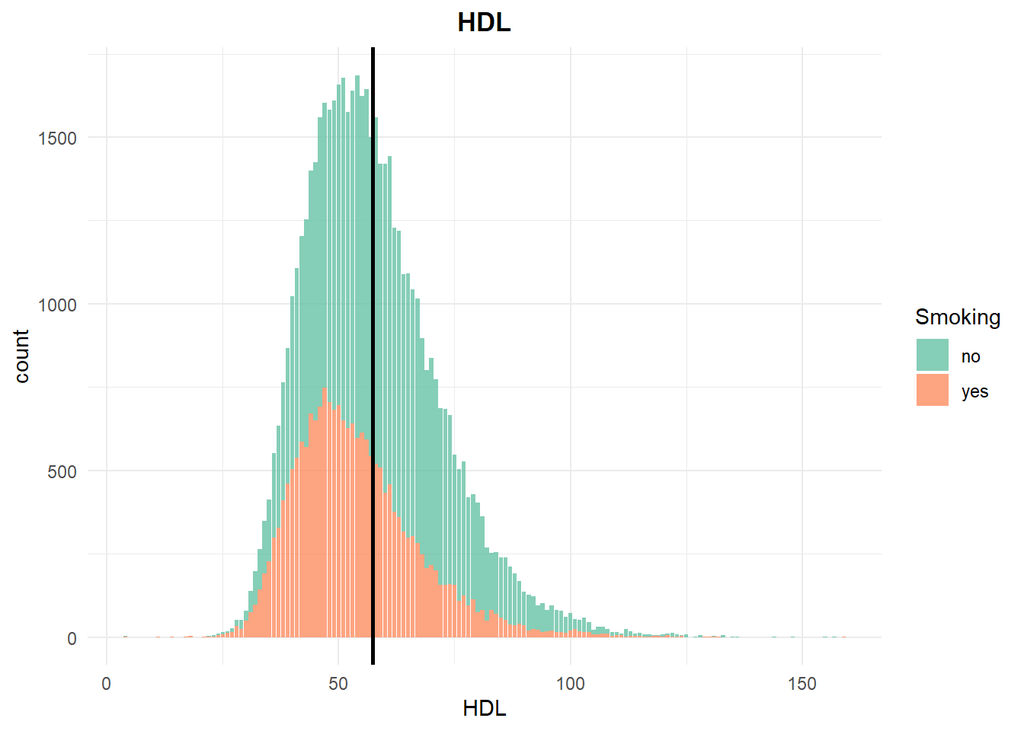

```r
ggplot(subset(smoke,smoke$HDL<200), aes(x=HDL, fill=as.factor(smoking)))+
  geom_bar(alpha=0.8)+
  labs(title="HDL", fill="Smoking")+
  theme_minimal()+
  theme(plot.title = element_text(face="bold", hjust=0.5))+
  scale_fill_brewer(label=c("no","yes"),palette="Set2")+
  geom_vline(aes(xintercept=mean(smoke$HDL)), col = "black", lwd = 1)
```

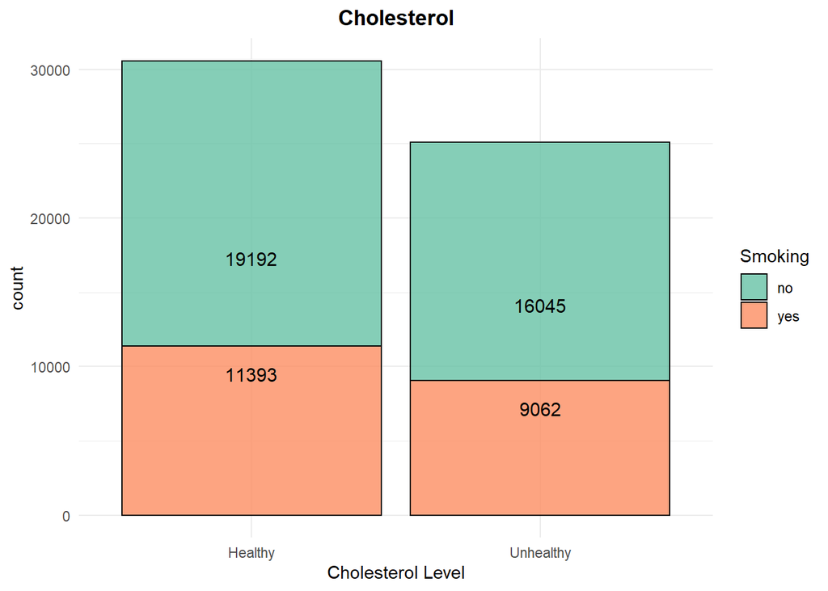

```r
#we have seen that the majority of the people in the dataset is aged between 19 and 50
smoke$chol_grp <- ifelse(smoke$cholesterol>=125 & smoke$cholesterol<=200,"Healthy", "Unhealthy")

ggplot(smoke,aes(x=as.factor(chol_grp), fill=as.factor(smoking)))+
  geom_bar(col="black", alpha=0.8)+
  scale_fill_brewer(label=c("no","yes"),palette="Set2")+
  labs(title="Cholesterol", fill="Smoking", x="Cholesterol Level")+
  geom_text(aes(label=..count..), stat="count", vjust=2.5, size=4)+
  theme_minimal()+
  theme(plot.title = element_text(face="bold", hjust=0.5))
```

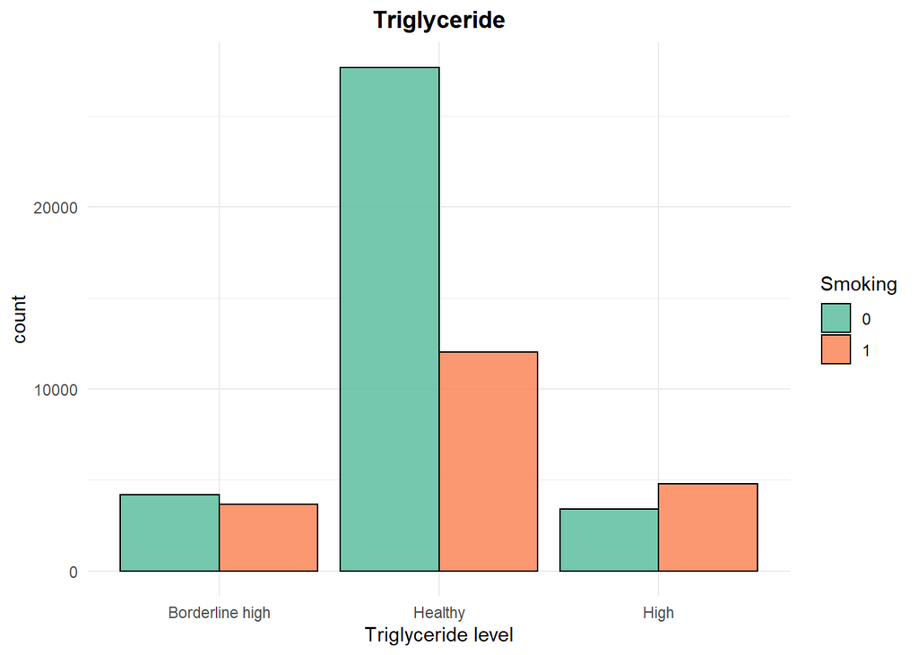

```r
table <- smoke%>% dplyr::select(c("triglyceride", "smoking")) %>%
  group_by(smoking) %>%
  summarise(trigly_mean = mean(triglyceride)) %>%
  mutate(., Type=ifelse(trigly_mean<150,"Healthy","Unhealthy"))

smoke$trigly_grp <- ifelse(smoke$triglyceride < 150, "Healthy",
                           ifelse((smoke$triglyceride >= 150 & smoke$triglyceride < 200), "Borderline high", "High"))

ggplot(smoke, aes(x= trigly_grp, fill = smoking))+
  geom_bar(position = "dodge", col = "black", alpha=0.9)+
  scale_fill_brewer(palette="Set2")+
  labs(title="Triglyceride", fill="Smoking", x="Triglyceride level")+
  theme_minimal()+
  theme(plot.title = element_text(face="bold", hjust=0.5))
```